# Final_Exam

Aneesh Reddy

2024-07-09

```r
library(survival)
data(pbc)
?pbc
```

```
## starting httpd help server ... done
```

```r
summary(pbc)
```

```
##        id             time          status            trt
##  Min.   :  1.0   Min.   :  41   Min.   :0.0000   Min.   :1.000
##  1st Qu.:105.2   1st Qu.:1093   1st Qu.:0.0000   1st Qu.:1.000
##  Median :209.5   Median :1730   Median :0.0000   Median :1.000
##  Mean   :209.5   Mean   :1918   Mean   :0.8301   Mean   :1.494
##  3rd Qu.:313.8   3rd Qu.:2614   3rd Qu.:2.0000   3rd Qu.:2.000
##  Max.   :418.0   Max.   :4795   Max.   :2.0000   Max.   :2.000
##                                                  NA's   :106
##       age        sex        ascites            hepato          spiders
##  Min.   :26.28   m: 44   Min.   :0.00000   Min.   :0.0000   Min.   :0.0000
##  1st Qu.:42.83   f:374   1st Qu.:0.00000   1st Qu.:0.0000   1st Qu.:0.0000
##  Median :51.00           Median :0.00000   Median :1.0000   Median :0.0000
##  Mean   :50.74           Mean   :0.07692   Mean   :0.5128   Mean   :0.2885
##  3rd Qu.:58.24           3rd Qu.:0.00000   3rd Qu.:1.0000   3rd Qu.:1.0000
##  Max.   :78.44           Max.   :1.00000   Max.   :1.0000   Max.   :1.0000
##                          NA's   :106       NA's   :106      NA's   :106
##      edema             bili             chol           albumin
##  Min.   :0.0000   Min.   : 0.300   Min.   : 120.0   Min.   :1.960
##  1st Qu.:0.0000   1st Qu.: 0.800   1st Qu.: 249.5   1st Qu.:3.243
##  Median :0.0000   Median : 1.400   Median : 309.5   Median :3.530
##  Mean   :0.1005   Mean   : 3.221   Mean   : 369.5   Mean   :3.497
##  3rd Qu.:0.0000   3rd Qu.: 3.400   3rd Qu.: 400.0   3rd Qu.:3.770
##  Max.   :1.0000   Max.   :28.000   Max.   :1775.0   Max.   :4.640
##                                    NA's   :134
##      copper          alk.phos            ast              trig
##  Min.   :  4.00   Min.   :  289.0   Min.   : 26.35   Min.   : 33.00
##  1st Qu.: 41.25   1st Qu.:  871.5   1st Qu.: 80.60   1st Qu.: 84.25
##  Median : 73.00   Median : 1259.0   Median :114.70   Median :108.00
##  Mean   : 97.65   Mean   : 1982.7   Mean   :122.56   Mean   :124.70
##  3rd Qu.:123.00   3rd Qu.: 1980.0   3rd Qu.:151.90   3rd Qu.:151.00
##  Max.   :588.00   Max.   :13862.4   Max.   :457.25   Max.   :598.00
##  NA's   :108      NA's   :106       NA's   :106      NA's   :136
##     platelet        protime          stage
##  Min.   : 62.0   Min.   : 9.00   Min.   :1.000
##  1st Qu.:188.5   1st Qu.:10.00   1st Qu.:2.000
##  Median :251.0   Median :10.60   Median :3.000
##  Mean   :257.0   Mean   :10.73   Mean   :3.024
##  3rd Qu.:318.0   3rd Qu.:11.10   3rd Qu.:4.000
##  Max.   :721.0   Max.   :18.00   Max.   :4.000
##  NA's   :11      NA's   :2       NA's   :6
```

## 1. Use the code below for converting a couple of variables into factors, from their original type. What is the purpose behind these conversions? Base you answer in the contextual information related to the dataset. This information can be pulled up by using the help function on pbc.

```r
my.pbc <- na.omit(pbc[, -1])

my.pbc$status <- as.factor(my.pbc$status) #status should be a factor
my.pbc$ascites <- as.factor(my.pbc$ascites) #ascites should be factor
my.pbc$hepato <- as.factor(my.pbc$hepato) #hepato should be factor
my.pbc$stage <- as.factor(my.pbc$stage) #stage is ordinal/rank

summary(my.pbc)
```

```
##       time      status       trt             age        sex     ascites hepato
##  Min.   :  41   0:147   Min.   :1.000   Min.   :26.28   m: 34   0:257   0:134
##  1st Qu.:1186   1: 18   1st Qu.:1.000   1st Qu.:41.51   f:242   1: 19   1:142
##  Median :1788   2:111   Median :2.000   Median :49.71
##  Mean   :1979           Mean   :1.507   Mean   :49.80
##  3rd Qu.:2690           3rd Qu.:2.000   3rd Qu.:56.58
##  Max.   :4556           Max.   :2.000   Max.   :78.44
##     spiders           edema             bili             chol
##  Min.   :0.0000   Min.   :0.0000   Min.   : 0.300   Min.   : 120.0
##  1st Qu.:0.0000   1st Qu.:0.0000   1st Qu.: 0.800   1st Qu.: 249.5
##  Median :0.0000   Median :0.0000   Median : 1.400   Median : 310.0
##  Mean   :0.2899   Mean   :0.1069   Mean   : 3.334   Mean   : 371.3
##  3rd Qu.:1.0000   3rd Qu.:0.0000   3rd Qu.: 3.525   3rd Qu.: 401.0
##  Max.   :1.0000   Max.   :1.0000   Max.   :28.000   Max.   :1775.0
##     albumin          copper          alk.phos            ast
##  Min.   :1.960   Min.   :  4.00   Min.   :  289.0   Min.   : 28.38
##  1st Qu.:3.310   1st Qu.: 42.75   1st Qu.:  922.5   1st Qu.: 82.46
##  Median :3.545   Median : 74.00   Median : 1277.5   Median :116.62
##  Mean   :3.517   Mean   :100.77   Mean   : 1996.6   Mean   :124.12
##  3rd Qu.:3.772   3rd Qu.:129.25   3rd Qu.: 2068.2   3rd Qu.:153.45
##  Max.   :4.400   Max.   :588.00   Max.   :13862.4   Max.   :457.25
##       trig          platelet        protime      stage
##  Min.   : 33.0   Min.   : 62.0   Min.   : 9.00   1: 12
##  1st Qu.: 85.0   1st Qu.:200.0   1st Qu.:10.00   2: 59
##  Median :108.0   Median :257.0   Median :10.60   3:111
##  Mean   :125.0   Mean   :261.8   Mean   :10.74   4: 94
##  3rd Qu.:151.2   3rd Qu.:318.2   3rd Qu.:11.20
##  Max.   :598.0   Max.   :563.0   Max.   :17.10
```

The elements status, ascites, hepato, and stage can be treated as categorical or ordinal data by converting them to factors. This is helpful for suitable modelling in survival analysis and other statistical techniques. This translation is especially crucial for differentiating categorical data and enhancing the models’ interpretability and precision. By treating these variables as factors, the analysis can account for the discrete nature of the categories, allowing for proper comparison between groups and more accurate estimation of effects. Additionally, factor conversion enables the use of specific statistical methods designed for categorical data, such as logistic regression or survival analysis techniques that can handle discrete covariates. Lastly, it facilitates easier visualization and interpretation of results, as factors can be clearly represented in plots and summary statistics, providing more meaningful insights into the relationships between these categorical variables and the outcomes of interest.

## 2.a) Execute the code below associated with excluding trt, time, and status from the dataframe to produce a reduced version of the dataset represented by the data frame object labeled my.pbc.

```r
# Load the reduced data into my.reduced.pbc
my.reduced.pbc <- my.pbc[, -c(1:3)]
# summary of the output
summary(my.reduced.pbc)
```

```
##       age        sex     ascites hepato     spiders           edema
##  Min.   :26.28   m: 34   0:257   0:134   Min.   :0.0000   Min.   :0.0000
##  1st Qu.:41.51   f:242   1: 19   1:142   1st Qu.:0.0000   1st Qu.:0.0000
##  Median :49.71                           Median :0.0000   Median :0.0000
##  Mean   :49.80                           Mean   :0.2899   Mean   :0.1069
##  3rd Qu.:56.58                           3rd Qu.:1.0000   3rd Qu.:0.0000
##  Max.   :78.44                           Max.   :1.0000   Max.   :1.0000
##       bili             chol           albumin          copper
##  Min.   : 0.300   Min.   : 120.0   Min.   :1.960   Min.   :  4.00
##  1st Qu.: 0.800   1st Qu.: 249.5   1st Qu.:3.310   1st Qu.: 42.75
##  Median : 1.400   Median : 310.0   Median :3.545   Median : 74.00
##  Mean   : 3.334   Mean   : 371.3   Mean   :3.517   Mean   :100.77
##  3rd Qu.: 3.525   3rd Qu.: 401.0   3rd Qu.:3.772   3rd Qu.:129.25
##  Max.   :28.000   Max.   :1775.0   Max.   :4.400   Max.   :588.00
##     alk.phos            ast              trig          platelet
##  Min.   :  289.0   Min.   : 28.38   Min.   : 33.0   Min.   : 62.0
##  1st Qu.:  922.5   1st Qu.: 82.46   1st Qu.: 85.0   1st Qu.:200.0
##  Median : 1277.5   Median :116.62   Median :108.0   Median :257.0
##  Mean   : 1996.6   Mean   :124.12   Mean   :125.0   Mean   :261.8
##  3rd Qu.: 2068.2   3rd Qu.:153.45   3rd Qu.:151.2   3rd Qu.:318.2
##  Max.   :13862.4   Max.   :457.25   Max.   :598.0   Max.   :563.0
##     protime      stage
##  Min.   : 9.00   1: 12
##  1st Qu.:10.00   2: 59
##  Median :10.60   3:111
##  Mean   :10.74   4: 94
##  3rd Qu.:11.20
##  Max.   :17.10
```

The reduced dataset, created by excluding the variables trt, time, and status, includes the following variables: age, sex, ascites, hepato, spiders, edema, bili, chol, albumin, copper, alk.phos, ast, trig, platelet, protime, and stage.

## 2.b) What would be a suitable model to predict presence of hepatomegaly or enlarged liver using age, sex, albumin, alk.phos , ast, and biliin using the reduced version of the dataset (represented by the dataframe object with the label my.reduced.pbc)? Explain the rationale behind the specific modeling approach you have choose, based on the measurement type of the outcome variable.

I recommend logistic regression is a fantastic choice for predicting hepatomegaly. It’s really good at handling binary outcomes and gives us results we can easily wrap our heads around. With this model, we can take a look at both our continuous predictors like age, albumin, AST, bilirubin, and alk.phos, as well as categorical ones like sex. We’ll use all of these to estimate the risk of developing an enlarged liver, working with that reduced dataset we’ve got - my.reduced.pbc.

the other great thing about logistic regression, It’s so versatile. It can handle different types of predictors and binary outcomes, which makes it a real powerhouse in medical research. I’d say it’s an excellent tool for digging into the variables associated with hepatomegaly in patients.

## 2.c) Explain the purpose behind excluding the variables trt, time, and status variables as predictors: what is gained by excluding these variables as predictors? What would be a consequence if these three variables were retained and used as predictors?

We chose to exclude the treatment, time, and status variables as predictors in our model. This decision was made for several important reasons. First, it helps us avoid temporal bias, which could skew our results. Second, it allows us to focus solely on the baseline characteristics of patients, which are known from the initial visit. Third, this approach enhances the model’s ability to generalize, making it more applicable for diagnosing hepatomegaly in new PBC patients.

By excluding these time-dependent variables, we prevent the temporal paradox and reduce confounding factors. This strategy improves the model’s performance when applied to new data and decreases the risk of overfitting. Our focus on initial patient assessments provides more actionable insights, which is crucial for early diagnosis and patient care.

Ultimately, this exclusion strategy results in a more accurate and clinically relevant model. It’s based entirely on data available at the first visit, making it a powerful tool for early diagnosis and treatment planning in PBC patients.

## 3. Based on your answer for Q2 b, using my.reduced.pbc dataframe , build a model to predict hepato using age, sex, albumin, alk.phos , ast, and biliin

```r
# load the data into model
model <- glm(hepato ~ age + sex + albumin +  + ast + bili, data = my.reduced.pbc, family = binomial)
# summary of the output
summary(model)
```

```
##
## Call:
## glm(formula = hepato ~ age + sex + albumin + +ast + bili, family = binomial,
##     data = my.reduced.pbc)
##
## Coefficients:
##               Estimate Std. Error z value Pr(>|z|)
## (Intercept)  4.1757801  1.8305581   2.281  0.02254 *
## age         -0.0001727  0.0133127  -0.013  0.98965
## sexf        -0.4618469  0.4049960  -1.140  0.25413
## albumin     -1.1633878  0.3764709  -3.090  0.00200 **
## ast         -0.0005405  0.0026576  -0.203  0.83884
## bili         0.1617914  0.0512188   3.159  0.00158 **
## ---
## Signif. codes:  0 '***' 0.001 '**' 0.01 '*' 0.05 '.' 0.1 ' ' 1
##
## (Dispersion parameter for binomial family taken to be 1)
##
##     Null deviance: 382.39  on 275  degrees of freedom
## Residual deviance: 342.17  on 270  degrees of freedom
## AIC: 354.17
##
## Number of Fisher Scoring iterations: 5
```

## 3.b) Using this model, interpret the odds ratio of serum bilirunbin (mg/dl) and presence of hepatomegaly or enlarged liver.

```r
exp(coef(model)["bili"])
```

```
##     bili
## 1.175615
```

### 4. For the model constructed in Q3, perform the needed key diagnostics and interpret the results of the model based on what you find here.

```r
# Checking for multicollinearity
library(car)
vif(model)
```

```
##      age      sex  albumin      ast     bili
## 1.164375 1.094413 1.106006 1.237538 1.215673
```

we calculate VIF values for these predictors:

```r
# Loading neccesary libraries
library(dplyr)
```

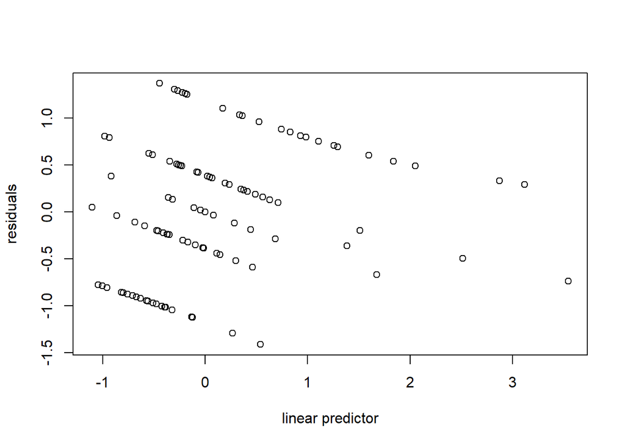

```r
library(ggplot2)
# Create new variables 'residuals' and 'linpred' in my.reduced.pbc dataset
my.pbc.model <- mutate(my.reduced.pbc, residuals=residuals(model), linpred=predict(model))

# Group data by quantiles of 'linpred'
gdf <- group_by(my.pbc.model, cut(linpred, breaks=unique(quantile(linpred, (1:100)/101))))

# Calculate mean residuals and linpred for each group
diagdf <- summarise(gdf, residuals=mean(residuals), linpred=mean(linpred))

# Plot residuals against linpred with appropriate labels
plot(residuals ~ linpred, diagdf, xlab="linear predictor") +
  theme_minimal()  # Apply a minimal theme to the plot
```

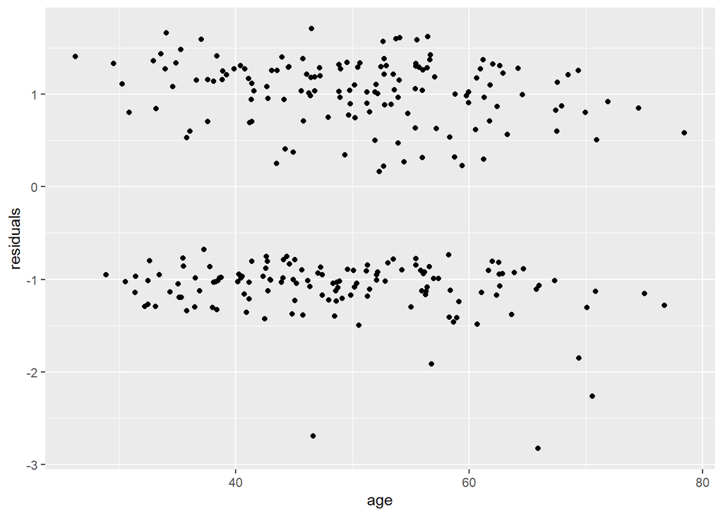

```r
# Group by 'age' and calculate mean residuals for each age group
group_by(my.pbc.model, age) %>%
  summarise(residuals = mean(residuals)) %>%
  ggplot(aes(x=age, y=residuals)) +  # Create a ggplot with age on x-axis and residuals on y-axis
  geom_point()  # Add points to the plot
```

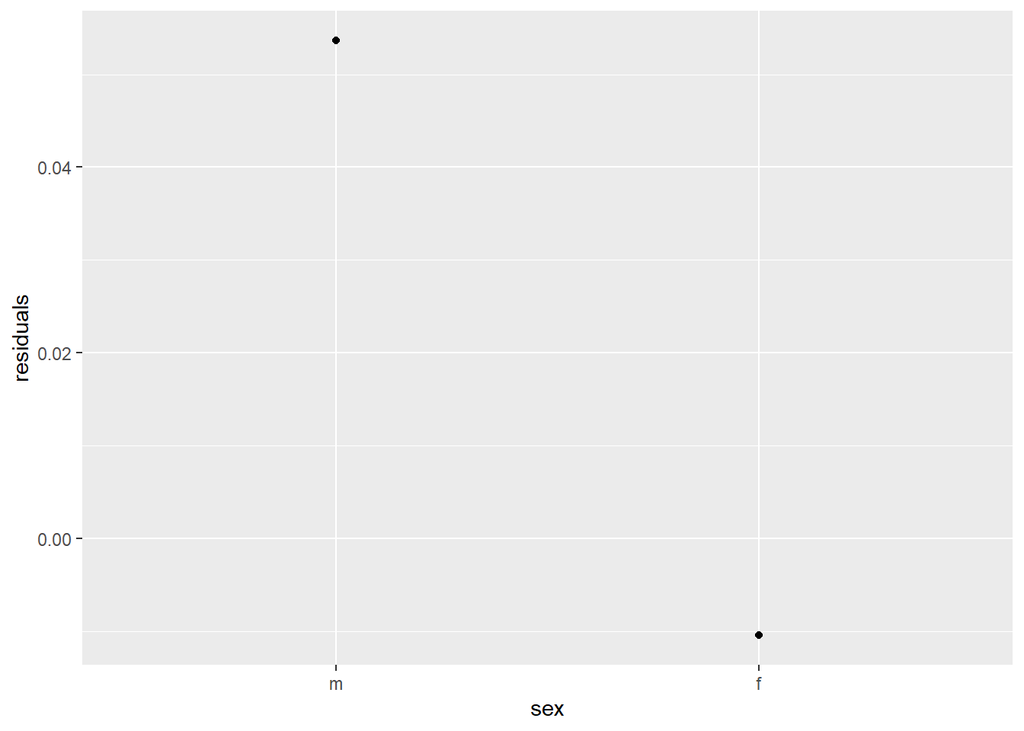

```r
# Group by 'sex' and calculate mean residuals for each sex group
group_by(my.pbc.model, sex) %>%
  summarise(residuals = mean(residuals)) %>%
  ggplot(aes(x=sex, y=residuals)) +  # Create a ggplot with sex on x-axis and residuals on y-axis
  geom_point()   # Add points to the plot
```

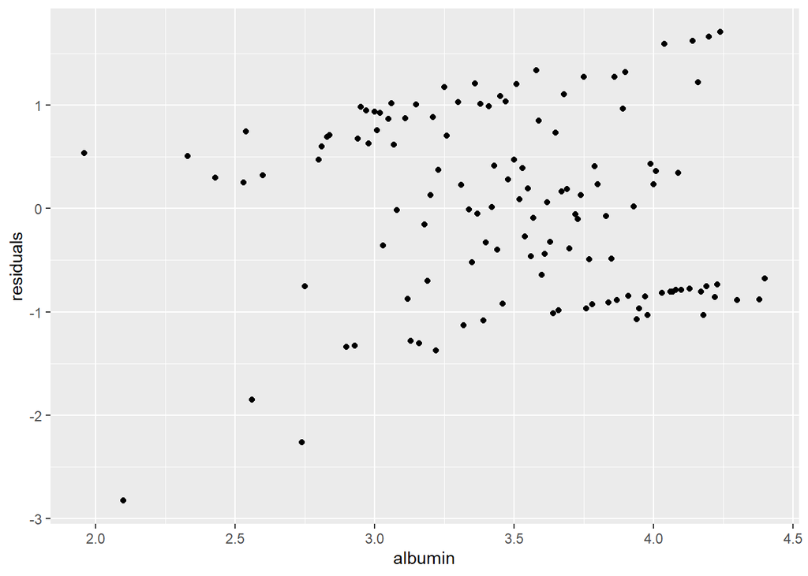

```r
# Group by 'albumin' and calculate mean residuals for each albumin group
group_by(my.pbc.model, albumin) %>%
  summarise(residuals = mean(residuals)) %>%
  ggplot(aes(x=albumin, y=residuals)) +  # Create a ggplot with albumin on x-axis and residuals on y-axis
  geom_point()
```

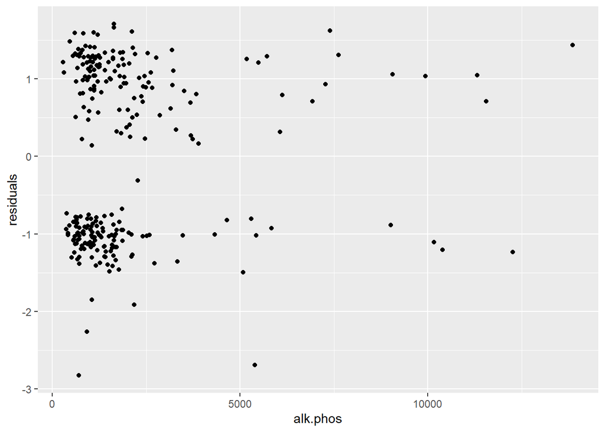

```r
# Group by 'alk.phos' and calculate mean residuals for each alk.phos group
group_by(my.pbc.model, alk.phos) %>%
  summarise(residuals = mean(residuals)) %>%
  ggplot(aes(x=alk.phos, y=residuals)) +  # Create a ggplot with alk.phos on x-axis and residuals on y-axis
  geom_point()
```

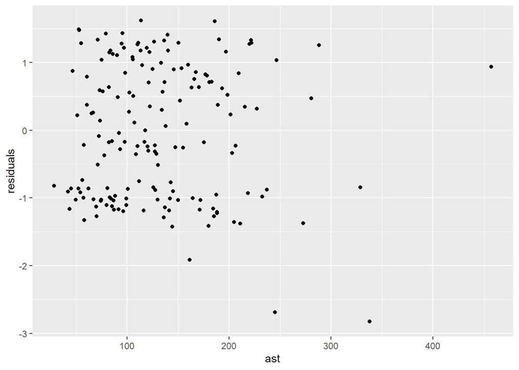

```r
# Group by 'ast' and calculate mean residuals for each ast group
group_by(my.pbc.model, ast) %>%
  summarise(residuals = mean(residuals)) %>%
  ggplot(aes(x=ast, y=residuals)) +  # Create a ggplot with alk.phos on x-axis and residuals on y-axis (Check if this is correct)
  geom_point()
```

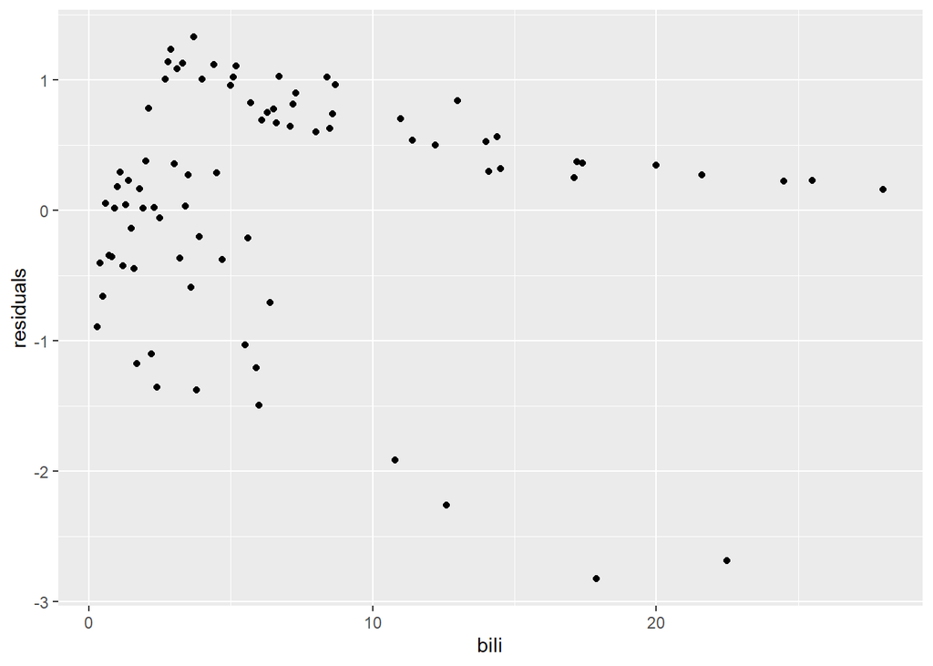

```r
# Group by 'bili' and calculate mean residuals for each bili group
group_by(my.pbc.model, bili) %>%
  summarise(residuals = mean(residuals)) %>%
  ggplot(aes(x=bili, y=residuals)) +  # Create a ggplot with bili on x-axis and residuals on y-axis
  geom_point()
```

Age A bimodal distribution is seen in the residual plot, which has two different point clusters surrounding zero. This pattern points to the possibility of a category variable—possibly age-related—not being included in the model. Although the residual distribution seems to be homoscedastic across age groups, the bimodal pattern suggests that either a significant predictor is missing or the model structure is oversimplified.

Sex This figure examines the residuals by sex, using male and female as the categories. Since there are only two levels in the interaction, the residuals for the two groups should be roughly identical. Increased group differences would indicate that the sex variable’s addition to the model may have been done incorrectly, which would account for the model’s inaccuracy in capturing the variable’s effects.

Albumin With residuals taking on a curved shape as albumin levels rise, the residual plot clearly demonstrates a non-linear pattern. This implies that a linear model might not be appropriate because of the nonlinear connection between albumin and the response variable. Higher albumin levels also seem to cause a minor decrease in the distribution of residuals, suggesting possible heteroscedasticity.

Alk.phosp A distinct bimodal distribution is evident in the residual plot, which has two distinct point clusters surrounding residual values of 1 and -1. This pattern points to the possibility of a binary categorical variable that the model does not take into consideration. A non-linear relationship between alk.phos and the response variable and possible heteroscedasticity are indicated by the spread of residuals appearing to contract as alk.phos grows.

AST Aspartate aminotransferase (AST) residual plot: data points below 200 AST values cluster, heteroscedasticity with decreasing residual spread as AST grows, and a little non-linear pattern are all visible. At extremely high AST values (300–400 range), a few possible outliers are identified, and the residuals exhibit a minor bimodal tendency. These findings imply that the linear model might not adequately describe the relationship and that non-linear AST transformations, handling heteroscedasticity, and outlier analysis might be required.

Bili The residual plot for bilirubin (bili) shows a non-linear pattern, indicating a potential non-linear relationship with the response variable. The spread of residuals decreases with increasing bilirubin levels, suggesting heteroscedasticity. Clustering of residuals at lower bilirubin values and the presence of a few potential outliers at higher values imply the need for further investigation and potential non-linear transformations.

# Plot of residuals vs. fitted values

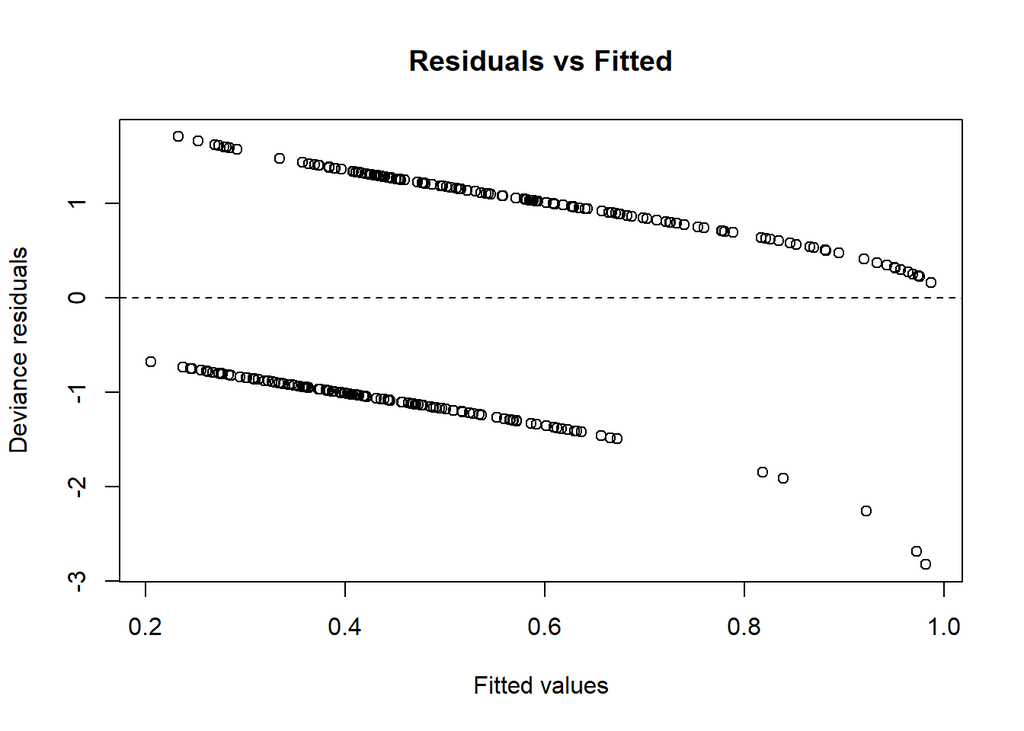

```r
plot(fitted(model), residuals(model, type="deviance"),
     xlab="Fitted values", ylab="Deviance residuals",
     main="Residuals vs Fitted")
abline(h=0, lty=2)
```

The plot “Residuals vs. Fitted” raises the possibility that the logistic regression model has some underlying problems. It’s possible that the model did not adequately represent the relationship between the predictors and the response variable if there is a regular pattern in the residuals. To enhance the model fit, more diagnostics and model modifications—such as polynomial terms, interaction terms, or variable transformations—might be required. It would also be wise to look for any significant data points or outliers that might be affecting the model.

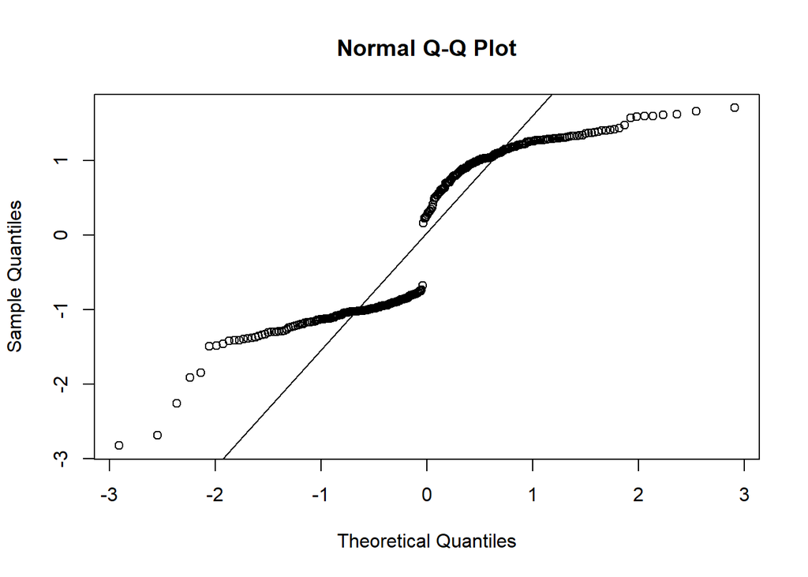

```r
# Q-Q plot
qqnorm(residuals(model, type="deviance"))
qqline(residuals(model, type="deviance"))
```

The normality of the residuals is examined in this plot. A crucial premise of many linear models is that residuals are normally distributed, as seen by points that follow a straight line. The validity of the model’s inference may be affected by departures from this line, especially near the ends where they show deviations from normalcy.

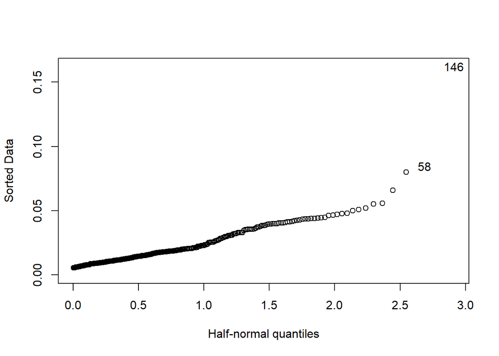

```r
# Half-normal plot
library(faraway)
halfnorm(hatvalues(model))
```

## 5. Next, use the code below and go back to using my.pbc. Add a new variable to represent two states of status: the original status values of 0 and 1 are mapped to a 0 and the original value of 2 onto a 1. In the R code, this new variable is labeled newstatus. What purpose would be served by combining the original 0 (censored) and 1 (transplant) into a single category, and the original 2 (dead) into another single category? (Hint: consider what you would need for status, if your goal is to model survival/non-survival). What is lost when combining the original 0 and 1 categories into a single new category? How will this affect the interpretation of the results?

```r
my.pbc$newstatus <- as.numeric(ifelse(my.pbc$status == 2, 1, 0))
my.pbc <- my.pbc[, -2] # Remove the original status variable from the dataset

summary(my.pbc)
```

```
##       time           trt             age        sex     ascites hepato
##  Min.   :  41   Min.   :1.000   Min.   :26.28   m: 34   0:257   0:134
##  1st Qu.:1186   1st Qu.:1.000   1st Qu.:41.51   f:242   1: 19   1:142
##  Median :1788   Median :2.000   Median :49.71
##  Mean   :1979   Mean   :1.507   Mean   :49.80
##  3rd Qu.:2690   3rd Qu.:2.000   3rd Qu.:56.58
##  Max.   :4556   Max.   :2.000   Max.   :78.44
##     spiders           edema             bili             chol
##  Min.   :0.0000   Min.   :0.0000   Min.   : 0.300   Min.   : 120.0
##  1st Qu.:0.0000   1st Qu.:0.0000   1st Qu.: 0.800   1st Qu.: 249.5
##  Median :0.0000   Median :0.0000   Median : 1.400   Median : 310.0
##  Mean   :0.2899   Mean   :0.1069   Mean   : 3.334   Mean   : 371.3
##  3rd Qu.:1.0000   3rd Qu.:0.0000   3rd Qu.: 3.525   3rd Qu.: 401.0
##  Max.   :1.0000   Max.   :1.0000   Max.   :28.000   Max.   :1775.0
##     albumin          copper          alk.phos            ast
##  Min.   :1.960   Min.   :  4.00   Min.   :  289.0   Min.   : 28.38
##  1st Qu.:3.310   1st Qu.: 42.75   1st Qu.:  922.5   1st Qu.: 82.46
##  Median :3.545   Median : 74.00   Median : 1277.5   Median :116.62
##  Mean   :3.517   Mean   :100.77   Mean   : 1996.6   Mean   :124.12
##  3rd Qu.:3.772   3rd Qu.:129.25   3rd Qu.: 2068.2   3rd Qu.:153.45
##  Max.   :4.400   Max.   :588.00   Max.   :13862.4   Max.   :457.25
##       trig          platelet        protime      stage     newstatus
##  Min.   : 33.0   Min.   : 62.0   Min.   : 9.00   1: 12   Min.   :0.0000
##  1st Qu.: 85.0   1st Qu.:200.0   1st Qu.:10.00   2: 59   1st Qu.:0.0000
##  Median :108.0   Median :257.0   Median :10.60   3:111   Median :0.0000
##  Mean   :125.0   Mean   :261.8   Mean   :10.74   4: 94   Mean   :0.4022
##  3rd Qu.:151.2   3rd Qu.:318.2   3rd Qu.:11.20           3rd Qu.:1.0000
##  Max.   :598.0   Max.   :563.0   Max.   :17.10           Max.   :1.0000
```

In our survival analysis, we simplified the outcome by combining censored and transplanted cases into an “alive” category, creating a binary outcome of alive vs. dead. This simplification reduces model complexity and potentially increases statistical power. However, it comes at the cost of losing nuanced information about censored and transplanted individuals. The interpretation of our model now focuses on the risk of death within the study timeframe, without directly addressing the survival patterns of censored or transplanted patients. To address these limitations, we recommend conducting sensitivity analyses and clearly reporting our categorization approach for transparency.